# CS 422: Section 04

Diego Martin Crespo

## 2.1 Problem

### a)

The excel file is oppened to see if the data has headers and to see what is the separation character that is used. And the file is loaded:

```r
library(dplyr)
library(psych)
college.df<-read.csv("College.csv",  header=TRUE, sep=',')
```

[output not shown]

### b)

To count the number of either private or public schools we use the table() function at column private. The result will give two numbers associated to the factor yes and no. “yes” is the number of private schools and “no” is supposed to be the number of public schools.

`r`r table= table(college.df$Private) table

```
 No Yes
212 565
```

### c)

We create two dataframes: one conatining the public colleges and other with the private. Also we plot the respective density histograms respect to the PhD students.

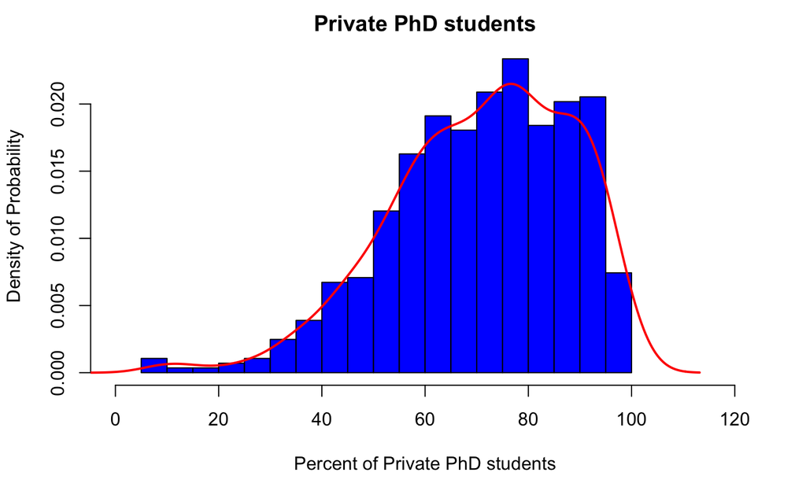

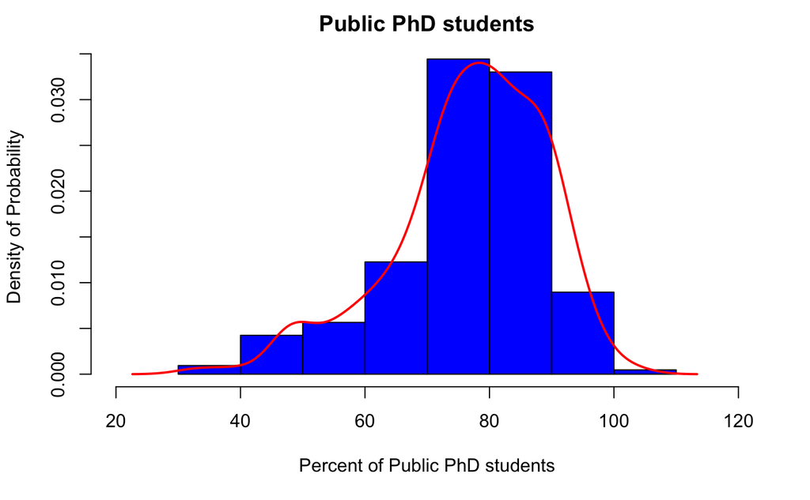

### d)

A new data frame is created shorted by Grad.Rate. The top min grades from the colleges are printed.

|  | Name | Grad.Rate |
| --- | --- | --- |
| 1 | Texas Southern University | 10 |
| 2 | Alaska Pacific University | 15 |
| 3 | Montreat-Anderson College | 15 |
| 4 | Brewton-Parker College | 18 |
| 5 | Claflin College | 21 |

Then the top max grades from the colleges are printed.

|  | Name | Grad.Rate |
| --- | --- | --- |
| 773 | Missouri Southern State College | 100 |
| 774 | Santa Clara University | 100 |
| 775 | Siena College | 100 |
| 776 | University of Richmond | 100 |
| 777 | Cazenovia College | 118 |

### e)

#### i.

Numerical summary of the variables of the dataset

`r`r summary(college.df)

```
                           Name     Private        Apps           Accept          Enroll       Top10perc
 Abilene Christian University:  1   No :212   Min.   :   81   Min.   :   72   Min.   :  35   Min.   : 1.00
 Adelphi University          :  1   Yes:565   1st Qu.:  776   1st Qu.:  604   1st Qu.: 242   1st Qu.:15.00
 Adrian College              :  1             Median : 1558   Median : 1110   Median : 434   Median :23.00
 Agnes Scott College         :  1             Mean   : 3002   Mean   : 2019   Mean   : 780   Mean   :27.56
 Alaska Pacific University   :  1             3rd Qu.: 3624   3rd Qu.: 2424   3rd Qu.: 902   3rd Qu.:35.00
 Albertson College           :  1             Max.   :48094   Max.   :26330   Max.   :6392   Max.   :96.00
 (Other)                     :771
   Top25perc      F.Undergrad     P.Undergrad         Outstate       Room.Board       Books           Personal
 Min.   :  9.0   Min.   :  139   Min.   :    1.0   Min.   : 2340   Min.   :1780   Min.   :  96.0   Min.   : 250
 1st Qu.: 41.0   1st Qu.:  992   1st Qu.:   95.0   1st Qu.: 7320   1st Qu.:3597   1st Qu.: 470.0   1st Qu.: 850
 Median : 54.0   Median : 1707   Median :  353.0   Median : 9990   Median :4200   Median : 500.0   Median :1200
 Mean   : 55.8   Mean   : 3700   Mean   :  855.3   Mean   :10441   Mean   :4358   Mean   : 549.4   Mean   :1341
 3rd Qu.: 69.0   3rd Qu.: 4005   3rd Qu.:  967.0   3rd Qu.:12925   3rd Qu.:5050   3rd Qu.: 600.0   3rd Qu.:1700
 Max.   :100.0   Max.   :31643   Max.   :21836.0   Max.   :21700   Max.   :8124   Max.   :2340.0   Max.   :6800

      PhD            Terminal       S.F.Ratio      perc.alumni        Expend        Grad.Rate
 Min.   :  8.00   Min.   : 24.0   Min.   : 2.50   Min.   : 0.00   Min.   : 3186   Min.   : 10.00
 1st Qu.: 62.00   1st Qu.: 71.0   1st Qu.:11.50   1st Qu.:13.00   1st Qu.: 6751   1st Qu.: 53.00
 Median : 75.00   Median : 82.0   Median :13.60   Median :21.00   Median : 8377   Median : 65.00
 Mean   : 72.66   Mean   : 79.7   Mean   :14.09   Mean   :22.74   Mean   : 9660   Mean   : 65.46
 3rd Qu.: 85.00   3rd Qu.: 92.0   3rd Qu.:16.50   3rd Qu.:31.00   3rd Qu.:10830   3rd Qu.: 78.00
 Max.   :103.00   Max.   :100.0   Max.   :39.80   Max.   :64.00   Max.   :56233   Max.   :118.00
```

#### ii.

The lower triangle of the matrix shows the scatterplox matrix and the upper triangle shows the linear correlation between them.

`r`r pairs.panels(college.df[,1:10])

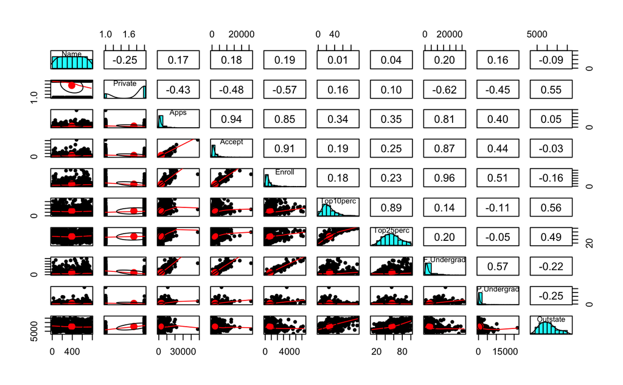

I consider the attributes that are related with each other those that have a value close to 0.5 or higher. #### iii. Which alumni donate more to their colleges, those who go to public schools or those who go to private schools?

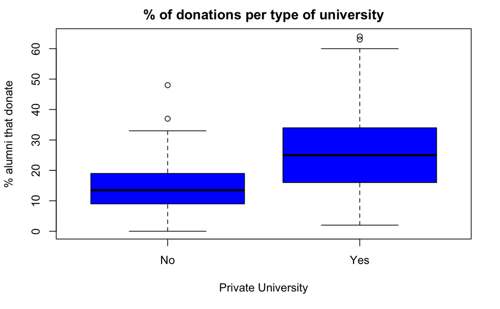

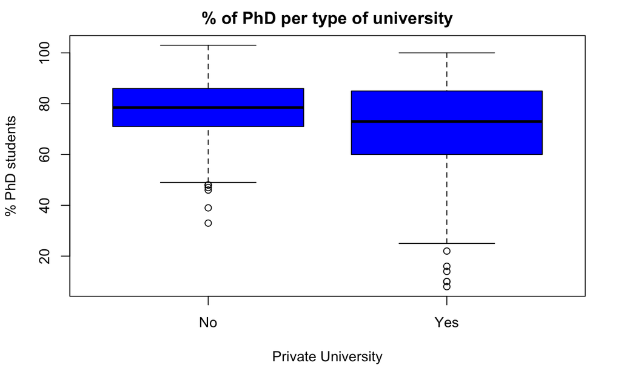

From this boxplot, we can observe that the mean number of PhDs hired in each university is close. Although the Public University has a smaller IQR, they hire more PhD’s #### v. Use summary() to see how many elite universities there are

```
 No Yes
699  78
```

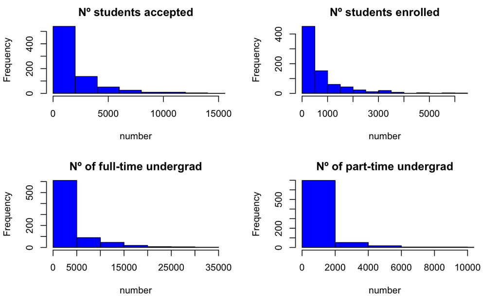

#### vii.

`r`r totalP<-mean((college.df$Accept-college.df$Enroll)/college.df$Accept)*100 under<-sum(college.df$P.Undergrad)/(sum(college.df$F.Undergrad)+sum(college.df$P.Undergrad))*100